[figure not shown]

# Validiraptor

[figure not shown]

## Description

**Validiraptor is an R package which provides a browser based UI to validate data for conformance with a schema.** Instances are provided by the user as flat CSV tables, schemas are retrieved from remote in JSON schema notation.

- Installation and usage
- Contributing
- Authors
- License
- Citation
- Acknowledgments

## Installation and usage

### Installation from GitHub

This **R** package ist available from GitHub only. Use {[remotes](https://cran.r-project.org/web/packages/remotes/index.html)} or {[pacman](https://cran.r-project.org/web/packages/pacman/index.html)} to install from the GitHub source:

```
  ## install {remotes} if necessary:
  if(!require("remotes")) install.packages("remotes")
  ## fetch and install {validiraptor}:
  remotes::install_github("eLTER-RI/validiraptor")
```

> On Windows, you need to download and install [Rtools](https://cran.r-project.org/bin/windows/Rtools/rtools43/rtools.html) to compile the source files retrieved from GitHub. Make sure to install the Rtools compatible with your R version (e. g. `RTools4.3` for R version 4.3).

After installation of the package, execute `validiraptor::run_app()` to launch the web app.

### Getting help

#### For users

In the running app (hosted or launched locally with `validiraptor::run_app()`), switch to the “demo” tab in the left sidebar for a choice of sample data to validate.

#### For users and developers

Visit https://elter-ri.github.io/validiraptor/ or execute `validiraptor::run_site()` to browse the documentation

#### For developers

Consult inline comments for internal functions which are not exported for use with `help()`

## Contributing

### Dependencies

- Dependencies on other R packages are declared in `DESCRIPTION` and resolved upon installation.
- Javascript dependencies are declared and included in `inst/app/www/js`

*To modify the javascript part of the validation functionality, change the source `validate.src.js` first, then [`browserify`](https://www.npmjs.com/package/browserify) the source to get the bundled `validate.js`*

- R code is tested with {[testthat](https://testthat.r-lib.org/)}. The test scripts go into `tests/testthat/`.

### Coding standards

To maintain the quality and readability of our code, we follow certain coding standards. Contributors are expected to adhere to these guidelines when writing code for this project:

#### Style

- Our R code adheres to the [tidyverse style guide](https://style.tidyverse.org/). Key points include:
  - Name variables and functions in `snake_case` (except `camelCase` for IDs of Shiny UI elements)
  - Place spaces around all binary operators (=, +, -, <-, etc.), except in function arguments.
  - Always assign `<-`, not `=`

#### Paradigm

- Please stick to R’s [functional approach](https://adv-r.hadley.nz/fp.html) and make liberal use of the native pipe operator `|>` to prevent scope mess and increase readability.

## Features / process

### 0

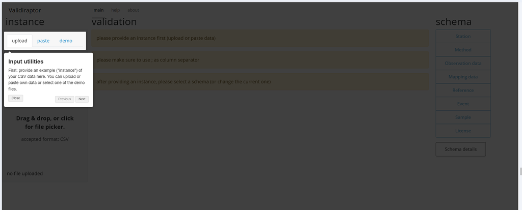

After launch, the user is briefly walked through the interaction options.

### 1

[figure not shown]

The user has to provide (upload / paste / pick demo data) CSV data for validation.

### 2

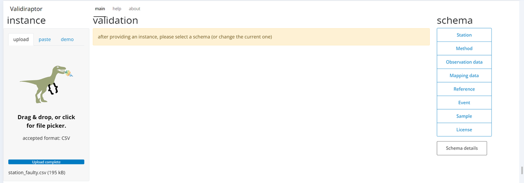

Next, a ruleset (schema) has to be selected.

### 3

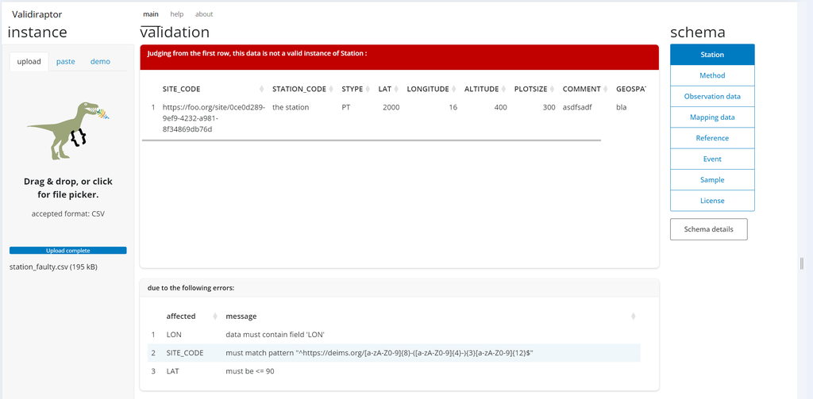

After specification of CSV data and validation rules, the validation results are displayed in the main panel.

## Authors

| Author | Affiliation | ORCID | e-mail |
| --- | --- | --- | --- |
| Ivo Offenthaler | [Environment Agency Austria](https://ror.org/013vyke20) | 0000-0001-5793-6641 | validiraptor-dev@proton.me |

## License

- This project is licensed under the [EUPL License](https://eupl.eu/) - see the LICENSE file for details.

## Acknowledgments

Development & maintenance funded through:

[figure not shown]